# A GAMLSS re-analysis of an RT data set (with a focus on data’s shape)

Fernando Marmolejo-Ramos

20 abril, 2022

# Introduction

The following features GAMLSS techniques to model a data set. The data set will be from a study by Moret-Tatay [^1]. A short tutorial on GAMLSS can be found in Stasinopoulos et al. (2018) [^2].

The plan is to showcase GAMLSS techniques to model the data’s shape; i.e. skewness and kurtosis. A paper that describes this approach can be found in de Bastiani et al. (in press) [^3].

# Uploading the data

```r
# data can be easily uploaded via the 'import dataset' tab in R studio...
library(readxl)
data <- read_excel(file.choose())


# retaining correct RTs that are between 250 and 1800 milliseconds
data2 <- subset(data, RT<1800 & RT>250 & Accuracy==1)

# ensuring all variables of interest are well
data2$Participant <- as.factor(data2$Participant)
data2$Group <- as.factor(data2$Group)
data2$Condition <- as.factor(data2$Condition)
```

# Modelling the shape of the model

First some GAMLSS models are created. The models will consider all the distribution’s parameters. Specifically the Normal (N) and ExGaussian (EG) distributions are considered.

```r
library(gamlss)
# model
mu<-as.formula(RT ~ Group * Condition + random(Participant))
sigma<-mu
nu<-mu


# two-parameters normal model

N <- gamlss(mu,
            sigma.formula = sigma,
               family = NO,
               data=data2)
```

```
## GAMLSS-RS iteration 1: Global Deviance = 55770.06
## GAMLSS-RS iteration 2: Global Deviance = 55750.01
## GAMLSS-RS iteration 3: Global Deviance = 55747.46
## GAMLSS-RS iteration 4: Global Deviance = 55746.65
## GAMLSS-RS iteration 5: Global Deviance = 55746.34
## GAMLSS-RS iteration 6: Global Deviance = 55746.21
## GAMLSS-RS iteration 7: Global Deviance = 55746.16
## GAMLSS-RS iteration 8: Global Deviance = 55746.13
## GAMLSS-RS iteration 9: Global Deviance = 55746.11
## GAMLSS-RS iteration 10: Global Deviance = 55746.11
## GAMLSS-RS iteration 11: Global Deviance = 55746.1
## GAMLSS-RS iteration 12: Global Deviance = 55746.1
## GAMLSS-RS iteration 13: Global Deviance = 55746.1
## GAMLSS-RS iteration 14: Global Deviance = 55746.1
## GAMLSS-RS iteration 15: Global Deviance = 55746.1
```

```r
# three parameters exGaussian

EG <- gamlss(mu,
            sigma.formula = sigma,
            nu.formula = nu,
               family = exGAUS,
               data=data2)
```

```
## GAMLSS-RS iteration 1: Global Deviance = 56036.44
## GAMLSS-RS iteration 2: Global Deviance = 54949.05
## GAMLSS-RS iteration 3: Global Deviance = 54791.47
## GAMLSS-RS iteration 4: Global Deviance = 54749.35
## GAMLSS-RS iteration 5: Global Deviance = 54729.11
## GAMLSS-RS iteration 6: Global Deviance = 54715.12
## GAMLSS-RS iteration 7: Global Deviance = 54703.55
## GAMLSS-RS iteration 8: Global Deviance = 54694.41
## GAMLSS-RS iteration 9: Global Deviance = 54687.4
## GAMLSS-RS iteration 10: Global Deviance = 54682.42
## GAMLSS-RS iteration 11: Global Deviance = 54679.13
## GAMLSS-RS iteration 12: Global Deviance = 54677.08
## GAMLSS-RS iteration 13: Global Deviance = 54675.82
## GAMLSS-RS iteration 14: Global Deviance = 54674.92
## GAMLSS-RS iteration 15: Global Deviance = 54674.29
## GAMLSS-RS iteration 16: Global Deviance = 54673.84
## GAMLSS-RS iteration 17: Global Deviance = 54673.52
## GAMLSS-RS iteration 18: Global Deviance = 54673.29
## GAMLSS-RS iteration 19: Global Deviance = 54673.16
## GAMLSS-RS iteration 20: Global Deviance = 54673.06
```

Let’s examine the models’s AIC values and look at the residuals.

```r
# N and EG fits
list(normal_fit = N$aic, EG_fit = EG$aic)
```

```
## $normal_fit
## [1] 55985.14
##
## $EG_fit
## [1] 55018.92
```

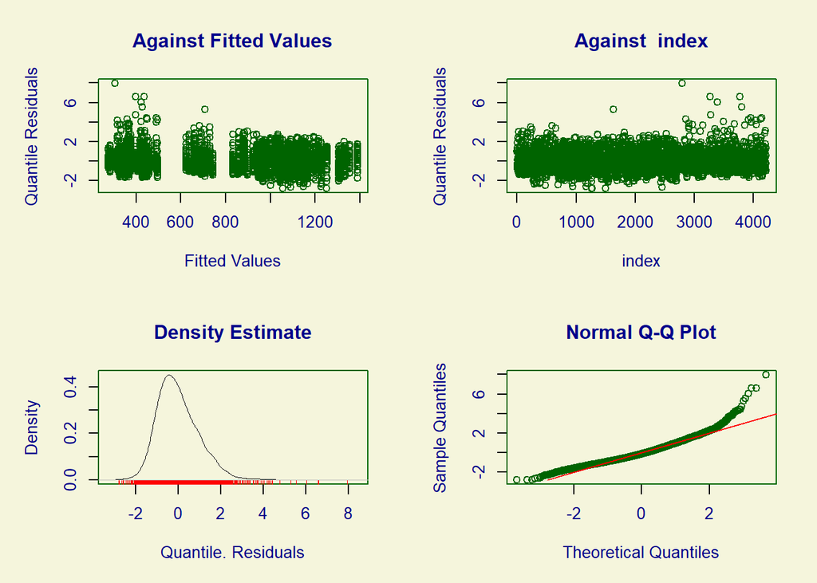

```
##        Summary of the Quantile Residuals
##                            mean   =  0.0004178385
##                        variance   =  1.000212
##                coef. of skewness  =  1.017315
##                coef. of kurtosis  =  6.100544
## Filliben correlation coefficient  =  0.9773554
```

```r
# residuals

plot(N)
```

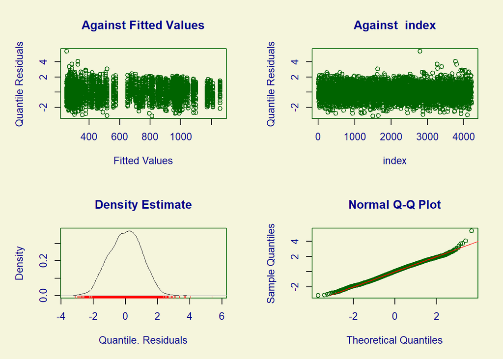

```
##        Summary of the Quantile Residuals
##                            mean   =  0.003946798
##                        variance   =  0.9963696
##                coef. of skewness  =  0.003782486
##                coef. of kurtosis  =  2.914012
## Filliben correlation coefficient  =  0.9984821
```

```r
plot(EG)
```

The EG model gives a better fit as shown by the AIC and the residual plots. Ideally, residuals should have a mean of 0, variance = 1, skewness = 0, and kurtosis = 3.

In case a list of distributions need to be inspected, the following marginal distribution fitting can assist in doing so.

```r
list<-fitDist(data2$RT, type='realplus')
```

```
##
##   Lapack routine dgesv: system is exactly singular: U[4,4] = 0
##
##   Lapack routine dgesv: system is exactly singular: U[4,4] = 0
##
```

```r
list
```

```
##
## Family:  c("BCPE", "Box-Cox Power Exponential")
## Fitting method: "nlminb"
##
## Call:  gamlssML(formula = y, family = DIST[i])
##
## Mu Coefficients:
## [1]  681.6
## Sigma Coefficients:
## [1]  -0.6037
## Nu Coefficients:
## [1]  0.04142
## Tau Coefficients:
## [1]  3.36
##
##  Degrees of Freedom for the fit: 4 Residual Deg. of Freedom   4214
## Global Deviance:     60644.1
##             AIC:     60652.1
##             SBC:     60677.5
```

The results indicate the four-parameters Box-Cox power exponential distribution gives the best fit. Let’s check the residuals:

```r
# four-parameters Box-Cox power exponential
tau <- mu

BCPE <- gamlss(mu,
            sigma.formula = sigma,
            nu.formula = nu,
            tau.formula = tau,
               family = BCPE,
               data=data2)
```

```
## GAMLSS-RS iteration 1: Global Deviance = 55001.69
## GAMLSS-RS iteration 2: Global Deviance = 54509.74
## GAMLSS-RS iteration 3: Global Deviance = 54395.26
## GAMLSS-RS iteration 4: Global Deviance = 54348.67
## GAMLSS-RS iteration 5: Global Deviance = 54324.52
## GAMLSS-RS iteration 6: Global Deviance = 54309.56
## GAMLSS-RS iteration 7: Global Deviance = 54299.29
## GAMLSS-RS iteration 8: Global Deviance = 54292.26
## GAMLSS-RS iteration 9: Global Deviance = 54287.11
## GAMLSS-RS iteration 10: Global Deviance = 54283.35
## GAMLSS-RS iteration 11: Global Deviance = 54280.31
## GAMLSS-RS iteration 12: Global Deviance = 54277.6
## GAMLSS-RS iteration 13: Global Deviance = 54274.99
## GAMLSS-RS iteration 14: Global Deviance = 54272.51
## GAMLSS-RS iteration 15: Global Deviance = 54270.36
## GAMLSS-RS iteration 16: Global Deviance = 54268.18
## GAMLSS-RS iteration 17: Global Deviance = 54266.28
## GAMLSS-RS iteration 18: Global Deviance = 54264.42
## GAMLSS-RS iteration 19: Global Deviance = 54262.34
## GAMLSS-RS iteration 20: Global Deviance = 54259.45
```

```r
# N and EG fits
list(BCPE_fit = BCPE$aic)
```

```
## $BCPE_fit
## [1] 54755.86
```

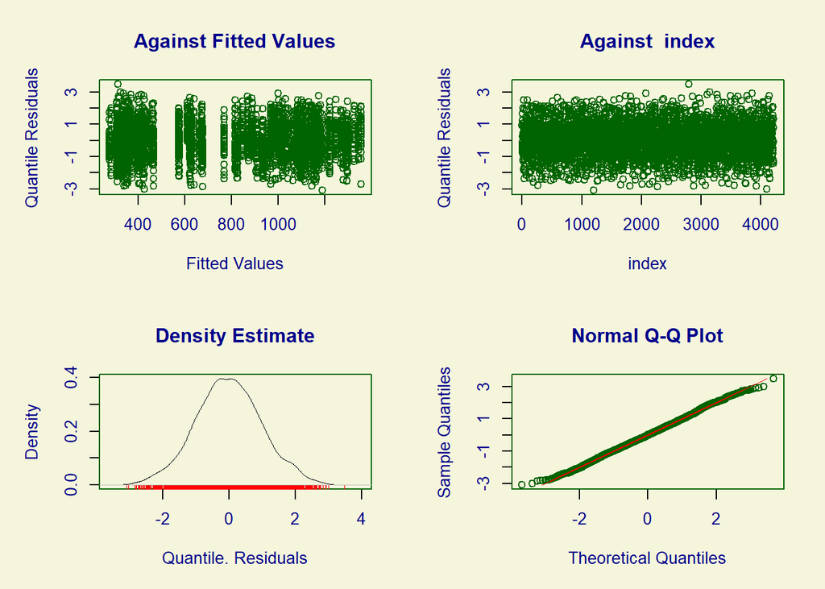

```
##        Summary of the Quantile Residuals
##                            mean   =  -0.01055977
##                        variance   =  0.9874408
##                coef. of skewness  =  0.04183484
##                coef. of kurtosis  =  2.952975
## Filliben correlation coefficient  =  0.999563
```

```r
# residuals

plot(BCPE)
```

The shape of the residuals and the AIC of the BCPE were better than those of the N and EG distributions.

## Buckeplots

### Buckeplots with existing data (an example)

First off, let’s illustrate these plots with existing data. In this example, only the location parameter is modelled and a P-spline is used on one of the numeric covariates.

```r
library(gamlss.ggplots)

bccg <- gamlss(R~pb(Fl)+A+B, data=rent, family=BCCG)
```

```
## GAMLSS-RS iteration 1: Global Deviance = 28024.31
## GAMLSS-RS iteration 2: Global Deviance = 27962.92
## GAMLSS-RS iteration 3: Global Deviance = 27960.95
## GAMLSS-RS iteration 4: Global Deviance = 27960.78
## GAMLSS-RS iteration 5: Global Deviance = 27960.76
## GAMLSS-RS iteration 6: Global Deviance = 27960.75
## GAMLSS-RS iteration 7: Global Deviance = 27960.75
## GAMLSS-RS iteration 8: Global Deviance = 27960.75
```

```r
no <- gamlss(R~pb(Fl)+A+B, data=rent, family=NO)
```

```
## GAMLSS-RS iteration 1: Global Deviance = 28326.39
## GAMLSS-RS iteration 2: Global Deviance = 28326.39
```

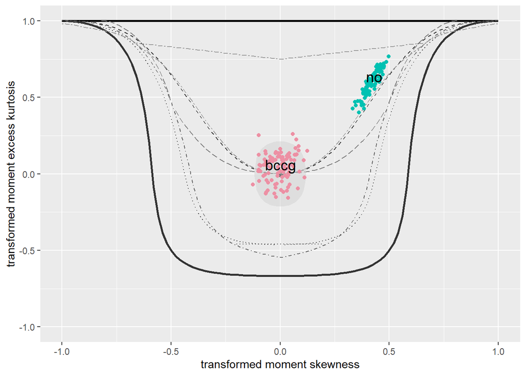

```r
moment_bucket(bccg, no, no_bootstrap = 100)
```

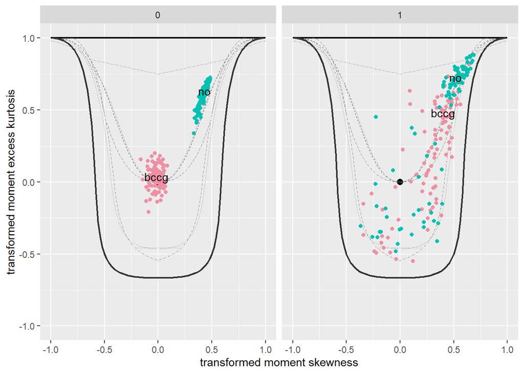

```r
# by a categorical covariate
moment_bucket_wrap(bccg, no, no_bootstrap = 100, xvar=rent$B)
```

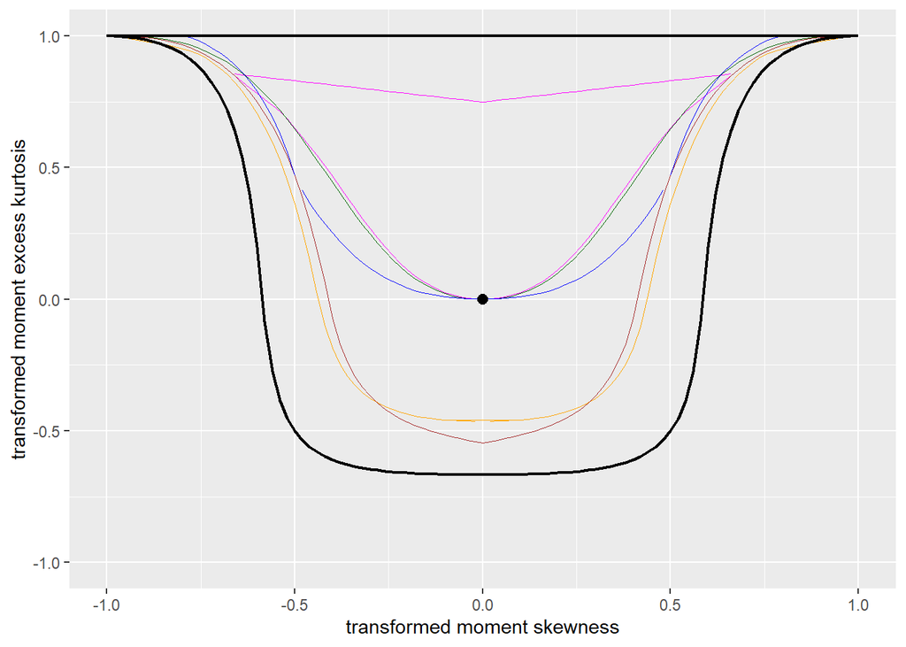

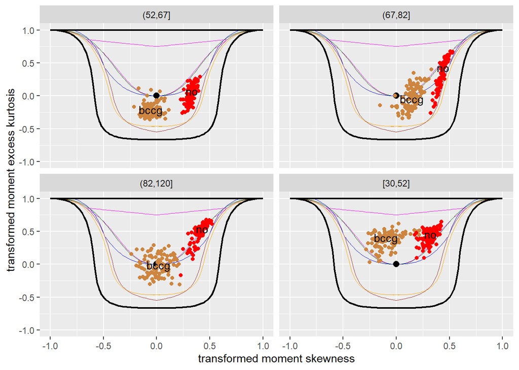

```r
moment_bucket_wrap(bccg, no, no_bootstrap = 100,
                   col_bootstrap = c('peru','red'),
                   colour_bucket = T,
                   # col_JB_test = 'pink',
                   xvar=rent$Fl)
```

Another function for bucketplots

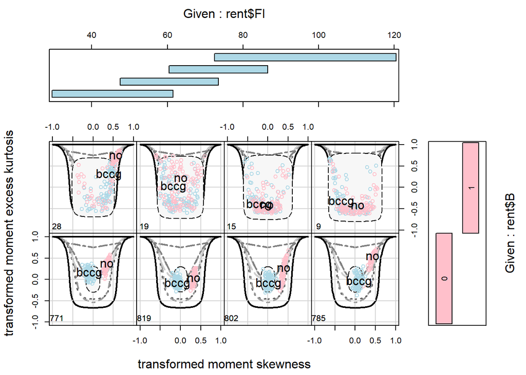

```r
# function 'bp' in the gamlss package does the job
# but note the 'overlap' argument seems not to be working! (see rent$Fl)
# note this argument applies to numeric covariates

# thus a function sent by Fernanda de Bastiani is used here
source("bp.R")

bp.fernanda(list(bccg,no), xvar=~rent$Fl*rent$B,
   show.legend = T,
   overlap = 0)
```

To fix the error in the argument `overlap` and generate more intuitive labels for the rows and columns, try the following

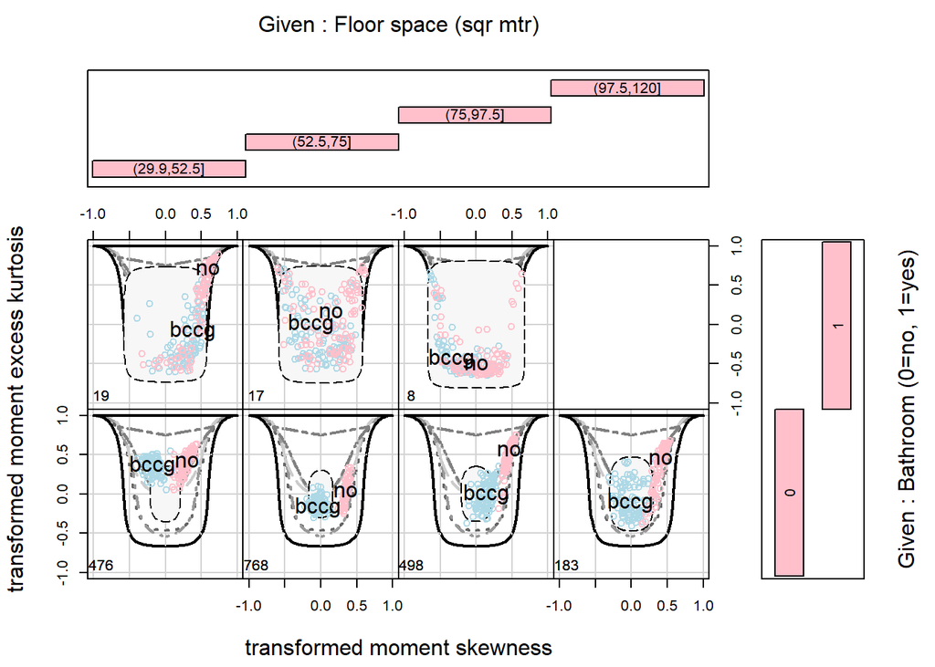

```r
`Floor space (sqr mtr)` <-cut(rent$Fl, 4)
# 4 cuts of equal length are requested
#note this doesn't entail equal number of observations in each level

`Bathroom (0=no, 1=yes)` <- rent$B

bp.fernanda(list(bccg,no),
   xvar=~`Floor space (sqr mtr)`*`Bathroom (0=no, 1=yes)`,
   show.legend = T,no.bootstrap = 99,
   overlap = 0)
```

### Buckeplots for current data

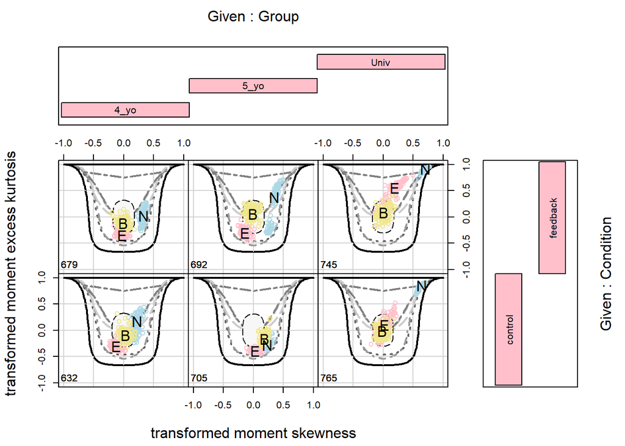

```r
# to give nicer looking labels for the rows and columns
Group <- data2$Group
Condition <- data2$Condition

# N=normal distribution, E=EG distribution, B=BCPE distribution

bp.fernanda(list(N,EG, BCPE), xvar=~Group*Condition,
   show.legend = T, no.bootstrap = 99,
   text.to.show = c('N','E','B'),
   overlap = 0)
```

[^1]: Moret-Tatay, C. et al. (2022). The effect of corrective feedback in basic cognitive tasks: a study in early childhood. *Children, 9*, 145. https://doi.org/10.3390/children9020145
[^2]: Stasinopoulos, M. D., Rigby, R. A., & Bastiani, F. D. (2018). GAMLSS: A distributional regression approach. *Statistical Modelling, 18*(3–4), 248–273.
[^3]: de Bastiani, F. et al (in press). Bucket plot: a visual tool for skewness and kurtosis comparisons. *Brazilian Journal of Probability and Statistics*